# Final Project

Jorden

10/16/2020

# Can Cinderellas Be Predicted in College Basketball

### Intro

Basketball is an incredibly intricate and complex game. There are so many factors that determine the winner of a game that it is almost impossible to distinguish which ones are primarily responsible for the outcome. College basketball in particular is especially unpredictable. The sheer amount of games that teams play, as well as the amount of teams there are in general create extreme unpredictability. That unpredictability reaches its peak in the annual tournament coined “March Madness”. March Madness is simply that, “madness”. The tournament is structured as follows : six rounds of single elimination basketball with matchups determined by the seed of the team. That seed that is supposed to correspond with the quality of a team, the closer a seed is to one the better a team is, while the closer a team is seeded to sixteen the worse a team is. In the first round the one seed will play the sixteen seed, the two seed will play the fifteen seed, the three seed will play the fourteen seed… etc. Sometimes a team will win multiple games that they weren’t supposed to win. Take Loyala Chicago for example, they came into the tournament as an 11 seed entering the 2018 tournament. An 11 seed has a 2.4% chance of making the final four (Boyd’s Bets). Yet they did. Loyola Chicago is an example of a Cinderella : a team that wins multiple games in the tournament that they were not supposed to. In this study, I wanted to see if there was a stat that people have been overlooking that could predict whether teams would become Cinderellas or not.

### Ethics

People have long struggled with making money through betting on sports, gamblers have lost thousands upon thousands of dollars doing so. Part of the thrill of gambling on sports is the knowledge that one could either make a million dollars, or lose everything. If I had found a statistical difference among Cinderella teams compared to normal teams, I would have had to be very careful about the way I presented it. If I presented it as a 100% truth, I could be misleading people to gamble more. Nothing in sports is 100% and portraying it as such is a dangerous and reckless notion. People could have lost thousands of dollars using my model. Ethically, could I present my model knowing that it was not 100% correct and that it could mislead people into gambling more money?

### Setup and Explanation of Data

I then combined these datasets together to form new, larger datasets that showed the trend for all teams called “allCombined”. I also created another dataset exclusively combining the NonCinderella and Balancers called “randoms” in order to conduct analysis on the teams in my datasets that were not considered Cinderellas.

### Description of Data

My data was made up of stats from 2006, 2008, 2011, 2013, 2014, 2015, 2016, 2017, and 2018 seasons compiled from the website Sports Reference (in .csv form). The observations in this dataset included fairly elementary values such as the team name, games played, wins, losses, total points scored, etc. The data then had to be wrangled to become useful using the mutate function. The main statistics I created using this function were based on the values the team had per game (averages) rather than the whole season. For example, I used the mutate function to create the statistic “points per game” by dividing the total points the team had scored by the number of games they played. I had to do this because some of the teams had played a different number of games than the others, and in order to evaluate the teams equally I had to evaluate them based on their averages and not their totals. I continued to do this for other stats such as strength of schedule per game (average strength of opposing team), opponent points per game, turnovers per game, and average margin of victory per game. I also used mutate to create a new variable called CinderellaStat which stated which type of team (Cinderella, Non-Cinderella, Balancer) a team was. This was done in order to make visualizing the data easier when combining the different datasets, for example, setting color to CinderellaStat would make it easier to compare the different datasets on the same plot.

### Creation of Teams Through Filtering Datasets

```r
#Cinderella
georgeMason <- filter(stats2005, School == "George Mason NCAA" )

davidson <- filter(stats2008, School == "Davidson NCAA" )


vcu <- filter(stats2011, School == "Virginia Commonwealth NCAA" )
butler <- filter(stats2011, School == "Butler NCAA" )
richmond <- filter(stats2011, School == "Richmond NCAA" )

wsu <- filter(stats2013, School == "Wichita State NCAA" )
fGCU <- filter(stats2013, School == "Florida Gulf Coast NCAA" )

kentucky2014 <- filter(stats2014, School == "Kentucky NCAA" )
uconn <- filter(stats2014, School == "Connecticut NCAA" )
dayton <- filter(stats2014, School == "Dayton NCAA" )
stanford <- filter(stats2014, School == "Stanford NCAA")

#lassalle
ncstate <- filter(stats2015, School == "North Carolina State NCAA" )

#ucla <- filter(stats2015, School == "UCLA NCAA" )

syracuse <- filter(stats2016, School == "Syracuse NCAA" )

xavier <- filter(stats2017, School == "Xavier NCAA" )

floridaSt <- filter(stats2018, School == "Florida State NCAA" )
kansasSt <- filter(stats2018, School == "Kansas State NCAA" )
loyolaChicago <- filter(stats2018, School == "Loyola (IL) NCAA" )
#Noncinderellas
#12
yale <- filter(stats2016, School == "Yale NCAA")
littleRock <- filter(stats2016, School == "Little Rock NCAA")
olemiss <- filter(stats2013, School == "Mississippi NCAA")
#13
morehead <- filter(stats2011, School == "Morehead State NCAA")
marshall <- filter(stats2018, School == "Marshall NCAA" )
#14
harvard <- filter(stats2013, School == "Harvard NCAA" )
sfa2016 <- filter(stats2016, School == "Stephen F. Austin NCAA" )
uab <- filter(stats2015, School == "Alabama-Birmingham NCAA" )
#15
midTennessee <- filter(stats2016, School == "Middle Tennessee NCAA" )
#16
uMBC <- filter(stats2018, School == "Maryland-Baltimore County NCAA" )
#random teams
uvm <- filter(stats2017, School == "Vermont NCAA" )
wsu2014 <- filter(stats2014, School == "Wichita State NCAA" )
michigan2014 <- filter(stats2014, School == "Michigan NCAA" )
florida2014 <- filter(stats2014, School == "Florida NCAA" )
wofford <- filter(stats2014, School == "Wofford NCAA" )
calPoly <- filter(stats2014, School == "Cal Poly NCAA" )
albany <- filter(stats2014, School == "Albany (NY) NCAA" )
easternK <- filter(stats2014, School == "Eastern Kentucky NCAA" )

kentucky2015 <- filter(stats2015, School == "Kentucky NCAA" )
wvu2016 <- filter(stats2016, School == "West Virginia NCAA")
wvu2017 <- filter(stats2017, School == "West Virginia NCAA")
georgetown <- filter(stats2013, School == "Georgetown NCAA" )

weberSt <- filter(stats2016, School == "Weber State NCAA")
stonyBrook <- filter(stats2016, School == "Stony Brook NCAA")
holyCross <- filter(stats2016, School == "Holy Cross NCAA")
fresnoSt <- filter(stats2016, School == "Fresno State NCAA")
villanova2016 <- filter(stats2016, School == "Villanova NCAA")

michigan2018 <- filter(stats2018, School == "Michigan NCAA")
uva2018 <- filter(stats2018, School == "Virginia NCAA")
villanova2018 <- filter(stats2018, School == "Villanova NCAA")
wichita2018 <- filter(stats2018, School == "Wichita State NCAA")
msu <- filter(stats2018, School == "Michigan State NCAA")
miami <- filter(stats2018, School == "Miami (FL) NCAA")
```

### Forming New Datasets

```r
#These are the classic cinderella teams who made it far in the tournament and exceeded expectations
cinderella<-rbind(georgeMason,fGCU,loyolaChicago,davidson, uconn, kentucky2014, syracuse, wsu, dayton, vcu, butler, richmond,xavier,stanford,ncstate)

#Teams that maybe upset one team and lost the next game
nonCinderella <- rbind(uMBC,midTennessee, harvard,sfa2016,morehead,uab,marshall,yale, littleRock)

#called balancers bc they don't belong to the other two groups, random teams to compare Cinderella teams to
balancers<-rbind(uvm, michigan2014, wsu2014,  kentucky2015,wvu2016,georgetown,wvu2017,florida2014, weberSt, stonyBrook, holyCross, fresnoSt, uva2018, villanova2016,villanova2018,michigan2018, wichita2018, msu, miami, calPoly, wofford, albany, easternK)
```

### Manipulating Datasets

```r
#getting rid of unused columns / empty ones
cinderella<- select(cinderella, School, G, W, L, W.L., SRS, SOS, ConfW, ConfL, HomeW, AwayW, AwayL, Points, Opoints, MP,    FG, FGA,    FG.,    X3P,    X3PA,   X3P.,   FT, FTA,    FT.,    ORB,    TRB,    AST,    STL,    BLK,    TOV,    PF, TWins,  Seed)
nonCinderella<- select(nonCinderella, School, G, W, L, W.L., SRS, SOS, ConfW, ConfL, HomeW, AwayW, AwayL, Points, Opoints, MP,  FG, FGA,    FG.,    X3P,    X3PA,   X3P.,   FT, FTA,    FT.,    ORB,    TRB,    AST,    STL,    BLK,    TOV,    PF, TWins,  Seed)
balancers<- select(balancers, School, G, W, L, W.L., SRS, SOS, ConfW, ConfL, HomeW, AwayW, AwayL, Points, Opoints, MP,  FG, FGA,    FG.,    X3P,    X3PA,   X3P.,   FT, FTA,    FT.,    ORB,    TRB,    AST,    STL,    BLK,    TOV,    PF, TWins,  Seed)

allCombinedYears<-mutate(allCombinedYears, ppg = Points/G)%>%
  mutate(allCombinedYears, oPpg = Opoints/G) %>%
  mutate(avMarg = ppg-oPpg)

#using mutate to create new statistics that will be useful for evaluations

cinderella <- mutate(cinderella, ppg = Points/G)%>%
  mutate(cinderella, oPpg = Opoints/G) %>%
  mutate(cinderellaStat = "Cinderella") %>%
  mutate(avMarg = ppg-oPpg) %>%
  mutate(turnPerGame = TOV/G) %>%
  mutate(SOSPerGame = SOS/G)

nonCinderella <- mutate(nonCinderella, ppg = Points/G) %>%
  mutate(nonCinderella, oPpg = Opoints/G) %>%
  mutate(cinderellaStat = "NonCinderella") %>%
  mutate(avMarg = ppg-oPpg) %>%
  mutate(turnPerGame = TOV/G) %>%
  mutate(SOSPerGame = SOS/G)

balancers <- mutate(balancers, ppg = Points/G) %>%
  mutate(balancers, oPpg = Opoints/G) %>%
  mutate(cinderellaStat = "Balancers") %>%
  mutate(avMarg = ppg-oPpg) %>%
  mutate(turnPerGame = TOV/G) %>%
  mutate(SOSPerGame = SOS/G)

#combining Cinderella and non cinderella
combined <- rbind(nonCinderella, cinderella)
combined <- mutate(combined, ppg = Points/G) %>%
  mutate(combined, oPpg = Opoints/G) %>%
  mutate(avMarg = ppg-oPpg) %>%
  mutate(turnPerGame = TOV/G)%>%
  mutate(SOSPerGame = SOS/G)

#combining non-cinderella and balancers
randoms <-rbind(nonCinderella,balancers)
randoms <- mutate(randoms, ppg = Points/G) %>%
  mutate(randoms, oPpg = Opoints/G) %>%
  mutate(avMarg = ppg-oPpg) %>%
  mutate(turnPerGame = TOV/G)%>%
  mutate(SOSPerGame = SOS/G)
#combining Cinderella, non-Cinderella and balancers
allCombined <-rbind(nonCinderella, cinderella, balancers)
allCombined <- mutate(allCombined, ppg = Points/G) %>%
  mutate(allCombined, oPpg = Opoints/G) %>%
  mutate(avMarg = ppg-oPpg) %>%
  mutate(turnPerGame = TOV/G)%>%
  mutate(SOSPerGame = SOS/G)

#making datasets that are usuable with the means function, essentially removing anything non numeric which just happens to be the names
noNameCinderella<- select(cinderella, G, W, L, W.L., SRS, SOS, ConfW, ConfL, HomeW, AwayW, AwayL, Points, Opoints, MP,  FG, FGA,    FG.,    X3P,    X3PA,   X3P.,   FT, FTA,    FT.,    ORB,    TRB,    AST,    STL,    BLK,    TOV,    PF, TWins,  Seed, avMarg, oPpg, ppg, turnPerGame, SOSPerGame)
nonNameNonCinderella<- select(nonCinderella, G, W, L, W.L., SRS, SOS, ConfW, ConfL, HomeW, AwayW, AwayL, Points, Opoints, MP,   FG, FGA,    FG.,    X3P,    X3PA,   X3P.,   FT, FTA,    FT.,    ORB,    TRB,    AST,    STL,    BLK,    TOV,    PF, TWins,  Seed, avMarg, oPpg, ppg, turnPerGame, SOSPerGame)

noNameBalancers <- select(balancers, G, W, L, W.L., SRS, SOS, ConfW, ConfL, HomeW, AwayW, AwayL, Points, Opoints, MP,   FG, FGA,    FG.,    X3P,    X3PA,   X3P.,   FT, FTA,    FT.,    ORB,    TRB,    AST,    STL,    BLK,    TOV,    PF, TWins,  Seed, avMarg, oPpg, ppg, turnPerGame, SOSPerGame)

noNameCombined <- rbind(noNameBalancers, noNameCinderella,nonNameNonCinderella)
```

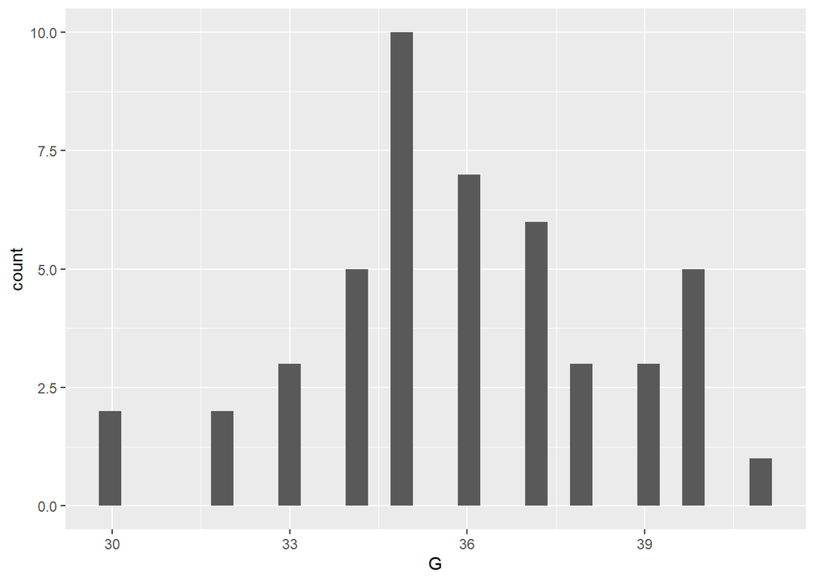

```r
ggplot(allCombined) + geom_histogram(aes(x = G))
```

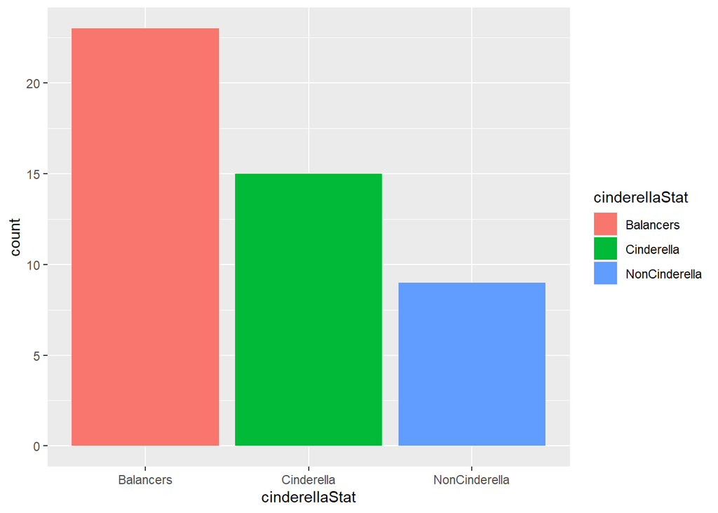

```r
cindStat <- select(allCombined, cinderellaStat)

ggplot(data = cindStat) + geom_bar(mapping = aes(x = cinderellaStat, fill = cinderellaStat))
```

Games Played Histogram Caption : The fact that there are many different values for the amount of games played showed me that I would have to adjust most statistics to be averages per game rather than season totals. For example, a team that plays 40 games is obviously going to have more total points than a team that played 30 games, thus adjusting it is necessary.

How many teams are in each category: This bar graph was necessary to create to show how many teams are in each of the categories I previously created. The amount of Balancers are so much higher than the other two categories because there were simply more options to pick from. While the Cinderella and Noncinderella categories were restricted to certain categories the Balancers category was not.

### Statistical Analysis and Interpretation

Continuing to evaluate whether SOSPG is a credible statistic to use when predicting which teams will be Cinderellas, I created a linear model to predict the amount of wins in the tournament a team would have based SOSPG using the predict function. After comparing the predicted results of the model with the actual data, I found the model was fairly inaccurate, often overestimating or underestimating a team’s wins in the tournament by 1. I found that supplementing SOSPG with another statistic such as “wins” the model somewhat more accurate, however, it was nowhere near 100% accurate. For example, while the model predicted that UMBC would win one game in the tournament, it also predicted that the team that they beat : Virginia would win four games. This shows that even the most promising of the stats(SOSPG) in my dataset was not able to accurately predict which teams would become Cinderellas.

#### Analyzing the means of the different types of teams (Cinderella, Non-Cinderella, Balancers)

```r
#Using the datasets that removed the team names to make new datasets showing the means for each stat
CinderellaMeans <- colMeans(noNameCinderella)
OneWinMeans <- colMeans(nonNameNonCinderella)
BalancerMeans <- colMeans(noNameBalancers)
means <- rbind(CinderellaMeans, BalancerMeans, OneWinMeans)
print(means)
```

```
##                        G        W         L      W.L.       SRS       SOS
## CinderellaMeans 37.60000 27.20000 10.400000 0.7229333 12.532000  5.713333
## BalancerMeans   35.56522 27.21739  8.347826 0.7603478 12.459130  3.574783
## OneWinMeans     34.11111 24.55556  9.555556 0.7207778  4.331111 -1.523333
##                    ConfW    ConfL    HomeW    AwayW    AwayL   Points  Opoints
## CinderellaMeans 12.33333 5.533333 13.06667 6.800000 5.266667 2707.933 2439.867
## BalancerMeans   13.43478 4.043478 13.65217 7.956522 4.652174 2634.391 2281.435
## OneWinMeans     13.44444 3.666667 13.44444 7.777778 6.555556 2509.556 2273.222
##                       MP       FG      FGA       FG.      X3P     X3PA
## CinderellaMeans       NA 948.6000 2085.733 0.4552000 266.0667 734.6667
## BalancerMeans   1433.261 925.7826 1997.043 0.4628696 263.3913 720.4348
## OneWinMeans     1376.556 881.2222 1929.889 0.4574444 258.5556 701.4444
##                      X3P.       FT      FTA       FT.      ORB      TRB
## CinderellaMeans 0.3620667 544.6667 777.3333 0.7008000 411.6667 1321.533
## BalancerMeans   0.3638696 519.3478 731.6087 0.7098696 373.8261 1247.783
## OneWinMeans     0.3683333 488.5556 698.3333 0.6994444 364.7778 1203.889
##                      AST      STL      BLK      TOV       PF    TWins      Seed
## CinderellaMeans 510.2667 248.2000 143.8000 447.0000 659.2000 3.533333 10.133333
## BalancerMeans   514.7391 236.4348 133.2609 394.7826 619.8261 1.391304  7.304348
## OneWinMeans     498.5556 244.5556 133.7778 433.8889 613.2222 1.000000 13.666667
##                   avMarg     oPpg      ppg turnPerGame  SOSPerGame
## CinderellaMeans 7.138575 64.87373 72.01231    11.89142  0.15127245
## BalancerMeans   9.727524 64.19192 73.91944    11.12938  0.09508205
## OneWinMeans     7.017533 66.49600 73.51353    12.73361 -0.04433790
```

#### Looking at Correlations between SOSPerGame and Twins in the different datasets

```r
cindSOs <- as.numeric(cinderella$SOSPerGame)
cindTWins <- as.numeric(cinderella$TWins)
cor(cindSOs,cindTWins)
```

```
## [1] 0.1637149
```

```r
#others
balSOS <- as.numeric(randoms$SOSPerGame)
balTWins <- as.numeric(randoms$TWins)
cor(balSOS, balTWins)
```

```
## [1] 0.5159354
```

As you can see, the correlation between TWins and SOSPG for Cinderellas was much less than the correlation for the ‘Randoms’. This shows that the model I create in the next step will be less accurate when measuring Cinderella teams as there is less of a relationship between SOSPG and TWins among Cinderella teams.

```r
# making a t test to measure the correlation between
#creating a model to try and accurately predict tournament wins using statistics
#use to see whether a team grossly overperformed or underperformed

predictedWins <- lm(TWins ~ SOSPerGame + W, allCombined)
selected <- select(allCombined, School, TWins)

predict(predictedWins)
```

```
##          1          2          3          4          5          6          7
##  0.8611388  1.2388960  0.4748442  1.1495108  0.9362752  0.6477408  1.3793442
##          8          9         10         11         12         13         14
##  0.8266315  1.9813617  2.0208229  1.2571118  2.7579467  2.2266355  3.4907307
##         15         16         17         18         19         20         21
##  3.1044367  2.1248676  2.8811775  2.1300372  2.2626553  2.4265668  2.3543216
##         22         23         24         25         26         27         28
##  2.4714146  2.0659657  1.9782459  1.6184188  2.9875604  3.2856894  4.5686818
##         29         30         31         32         33         34         35
##  2.7189210  2.3599087  2.9899165  4.2043634  0.8620991  0.8035675 -1.1837865
##         36         37         38         39         40         41         42
##  1.6050299  3.5381957  4.1331005  4.3657484  3.7256111  2.0472436  3.0847449
##         43         44         45         46         47
##  1.7494122 -0.3811153 -0.3342959 -0.3924913  0.5947962
```

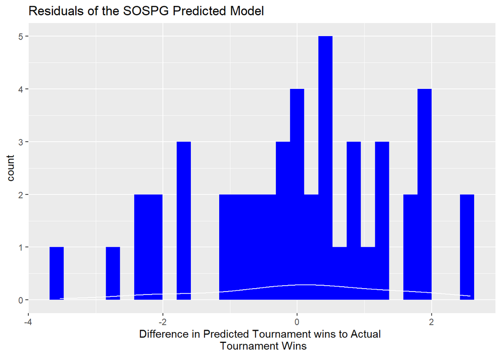

```r
#residuals of my prediction model

ggplot(predictedWins, aes(predictedWins$residuals), bins = 10)+ geom_histogram( fill = "blue") +geom_density(color = "white")+ ggtitle("Residuals of the SOSPG Predicted Model") +
  xlab("Difference in Predicted Tournament wins to Actual \n Tournament Wins") + ylab("count")
```

#### Residual Histogram Caption

This residual histogram and density plot shows that while a good portion of the predicted values for the amount of tournament wins were accurate, there were quite a few predictions that were off by a couple of games. This model obviously wasn’t 100% accurate.

### Relationship between Strength of Schedule Per Game and Tournament Wins By Different Categories

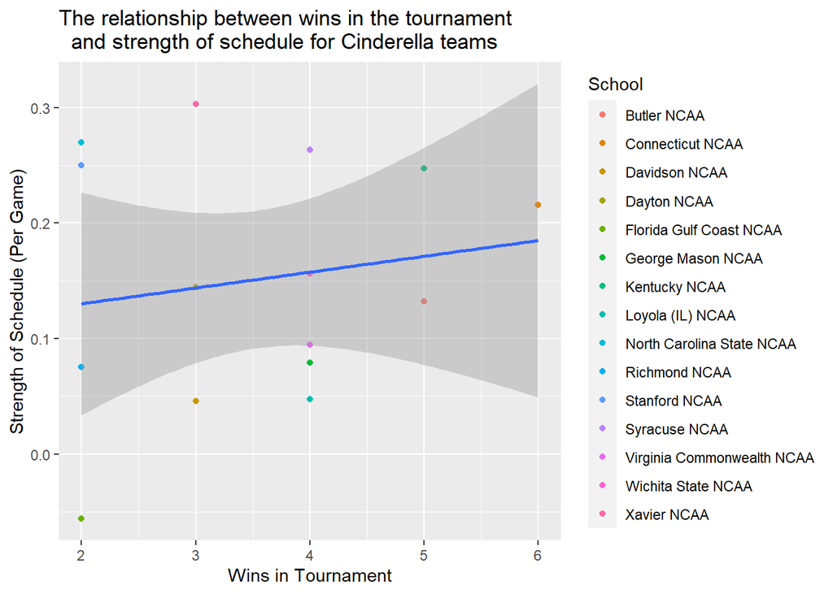

```r
#Checking to see if Cinderellas follow the same trend as others for SOS
#SOS was adjusted to per game because teams did not play the same amount of games
ggplot(cinderella)+geom_point(aes(x = TWins, y=SOSPerGame, color = School))+geom_smooth(method = 'lm', aes(x = TWins, y=SOSPerGame)) +ggtitle("The relationship between wins in the tournament\n  and strength of schedule for Cinderella teams")+ xlab('Wins in Tournament') + ylab("Strength of Schedule (Per Game)")
```

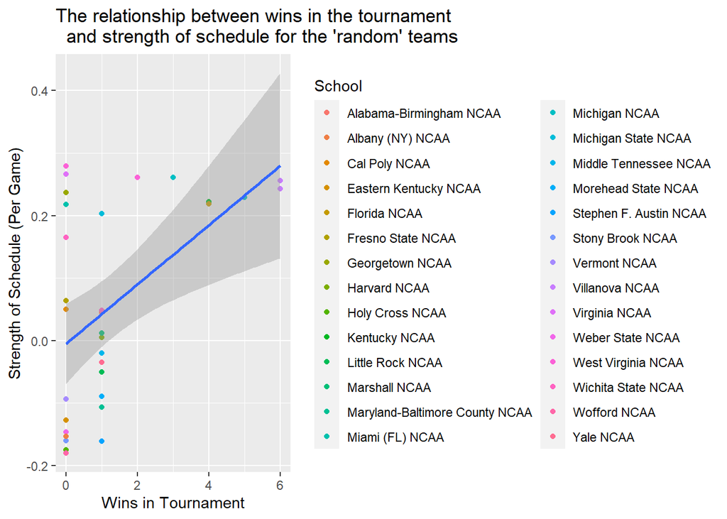

```r
ggplot(randoms)+geom_point(aes(x = TWins, y=SOSPerGame, color = School))+geom_smooth(method = 'lm', aes(x = TWins, y=SOSPerGame))+ggtitle("The relationship between wins in the tournament\n  and strength of schedule for the 'random' teams")+ xlab('Wins in Tournament') + ylab("Strength of Schedule (Per Game)")
```

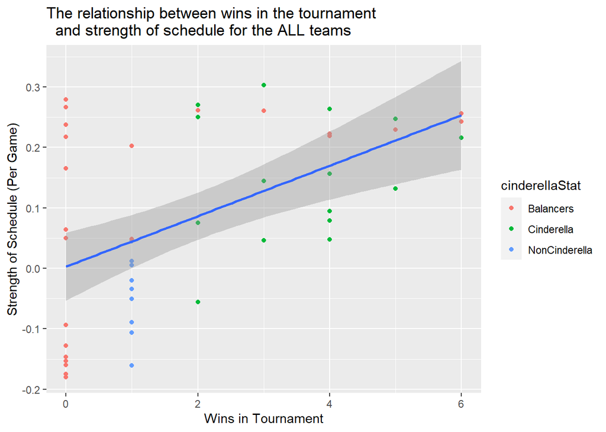

```r
#Plotting by cinderellaStat relationship between SOSPerGame and TWins
ggplot(allCombined)+geom_point(aes(x = TWins, y=SOSPerGame, color = cinderellaStat))+geom_smooth(method = 'lm', aes(x = TWins, y=SOSPerGame))+ggtitle("The relationship between wins in the tournament\n  and strength of schedule for the ALL teams")+ xlab('Wins in Tournament') + ylab("Strength of Schedule (Per Game)")
```

As referenced previously, these scatter plots further showed that the correlation between TWins and SOSPG was lower for Cinderella teams than random teams. This adds more evidence to the claim that the teams that become Cinderellas are random.

## Explanation For Randomness in College Basketball

Sometimes the better team just loses. For example, in 2018 Virginia went into the tournament as a 1 seed with 31 wins to their 3 loses and a strength of schedule of 9.07. To many experts they were the clear favorite to win the tournament despite the recent loss of their fourth leading scorer and starting forward De’Andre Hunter (Sports Reference). They drew 16 seed UMBC as their first round opponent. UMBC had compiled 25 wins to their 11 loses with a strength of schedule of -3.87. The discrepancy in strength of schedule is most notable because even though Virginia had a much tougher schedule according to the stats, they still had more wins than UMBC. Not only that, but in nearly every single statistical category Virginia had better stats while facing a harder schedule. Virginia allowed on average 14 points less per game than UMBC, while beating teams by an average margin of 13 points compared to UMBC’s average of 4 points. Worse for UMBC, no 16 seed had ever beaten a number 1 seed before. Both the odds and statistics were in Virginia’s favor, despite the loss of Hunter. What happened next shocked the basketball community : UMBC destroyed Virginia. UMBC scored 74 points, 20 more points than UVA gave up on average, while Virginia only scored 54 points, 10 points less than their season average. This is a prime example of a game that could not have been predicted by stats. Virginia clearly missed Hunter dearly. How can one quantitate the loss of a starting player. There are many implicit parts of basketball that cannot be measured by stats such as momentum and chemistry. The loss of Hunter clearly hurt Virginia’s chemistry dearly. It is also possible that UMBC played the best game of their lives, once again basketball is unpredictable. When this type of game happens multiple times a Cinderella is formed. This is a perfect example of the unpredictability of college basketball.

#### Code for Analyzing UMBC vs UVa

```r
refinedUVa<- filter(allCombined, School == "Virginia NCAA")
refinedUMBC <- filter(allCombined, School == "Maryland-Baltimore County NCAA")
uvaUMBC <- rbind(refinedUVa,refinedUMBC)

view(uvaUMBC)
```

## Conclusion

Once again, college basketball is extremely unpredictable, but then again sports aren’t supposed to be predictable. Outside of the observation that any team with a negative SOSPG is likely to not get past the second round and thus teams with a negative SOSPG are extremely unlikely to become Cinderellas, I was unable to find a statistic that could reliably be used to predict what teams would become Cinderellas. In doing so accept the null hypothesis that there is no stat that can do so. As Brian Mull stated in an NCAA.com article : “Chartier has crafted statistical models for teams built around a superstar like Curry, but they haven’t produced reliable results. So maybe there’s magic in March that can’t be quantified.” (Mull). I think that ultimately not having data points for the Cinderella teams hindered my analysis more than anything else. I think that in the future once there are more data points for Cinderella teams, there will be a way to better predict which teams will shock the country. Or, maybe the process of becoming a Cinderella will remain completely random and a mystery.

#### Works Cited

Works Cited https://bleacherreport.com/articles/2764254-virginias-deandre-hunter-to-miss-ncaa-tournament-after-suffering-wrist-injury https://www.sports-reference.com/cbb/schools/virginia/2018.html https://www.boydsbets.com/bracket-tips-by-seed https://www.ncaa.com/news/basketball-men/2019-03-06/march-madness-three-traits-cinderella-must-have

#### Random analysis I conducted in the process of making this project

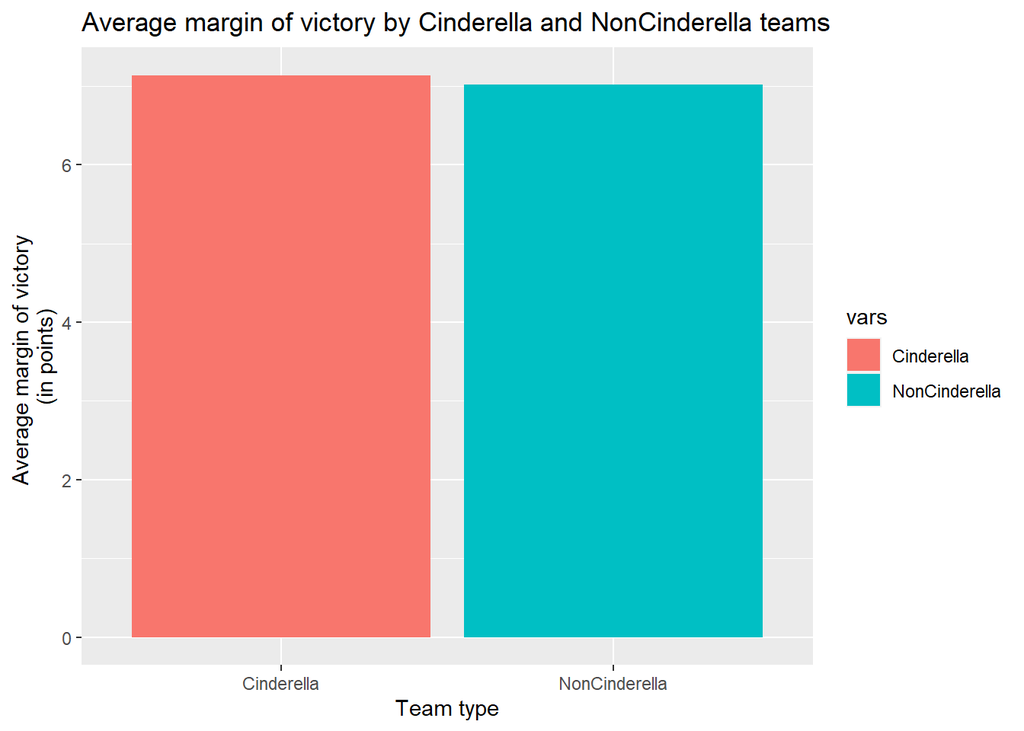

```r
#comparing cinderellas and one hit wonders
cindavMarg <- mean(cinderella$avMarg)
nonCinavMarg <- mean(nonCinderella$avMarg)
cindWins <- mean(cinderella$W)
nonCindWins <-mean(nonCinderella$W)
vars <- c('Cinderella','NonCinderella')
means <- c(cindavMarg, nonCinavMarg)
wins <- c(cindWins, nonCindWins)
data <- data.frame(vars,means)
View(data)
ggplot(data, aes(x =vars, y = means, fill = vars))+geom_bar(stat="identity") +ggtitle("Average margin of victory by Cinderella and NonCinderella teams ")+ xlab('Team type') + ylab("Average margin of victory \n (in points) ")
```

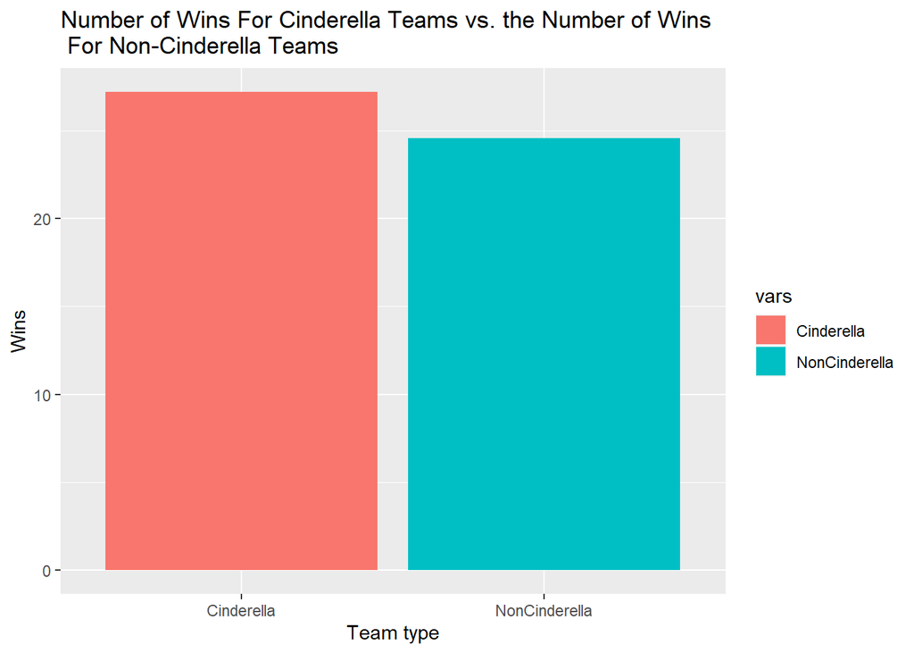

```r
ggplot(data, aes(x =vars, y = wins,fill = vars))+geom_bar(stat="identity") +ggtitle("Number of Wins For Cinderella Teams vs. the Number of Wins\n For Non-Cinderella Teams ")+ xlab('Team type') + ylab("Wins")
```

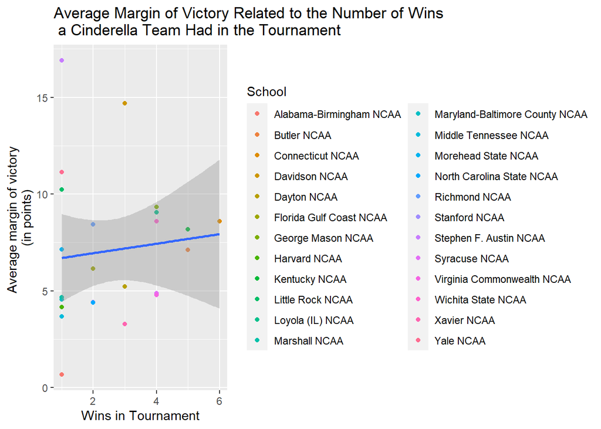

```r
#TO DO

# adjust ppg and oppg by yearly averages

#ggplot(combined)+geom_point(aes(x = TWins, y=SOS, color = School))+geom_smooth(method =lm, aes(x = TWins, y=SOS))+ggtitle(" A Team's Strenth of Schedule \n Related to the Number of \n Wins They Had in the Tournament")+ xlab("Wins in Tournament")+ ylab("Strength of Schedule")
#cor(combined$TWins,combined$SOS)

#E



ggplot(combined)+geom_point(aes(x = TWins, y=avMarg,color = School))+geom_smooth(method =lm, aes(x = TWins, y=avMarg))+ggtitle("Average Margin of Victory Related to the Number of Wins \n a Cinderella Team Had in the Tournament")+ xlab("Wins in Tournament")+ ylab("Average margin of victory \n (in points) ")
```

```r
lm(avMarg~TWins, data = combined)
```

```
##
## Call:
## lm(formula = avMarg ~ TWins, data = combined)
##
## Coefficients:
## (Intercept)        TWins
##       6.458        0.246
```

```r
t.test(combined$TWins,combined$avMarg)
```

```
##
##  Welch Two Sample t-test
##
## data:  combined$TWins and combined$avMarg
## t = -5.4931, df = 31.189, p-value = 5.125e-06
## alternative hypothesis: true difference in means is not equal to 0
## 95 percent confidence interval:
##  -6.183893 -2.835808
## sample estimates:
## mean of x mean of y
##  2.583333  7.093184
```

```r
cor(combined$TWins,combined$avMarg)
```

```
## [1] 0.1055468
```

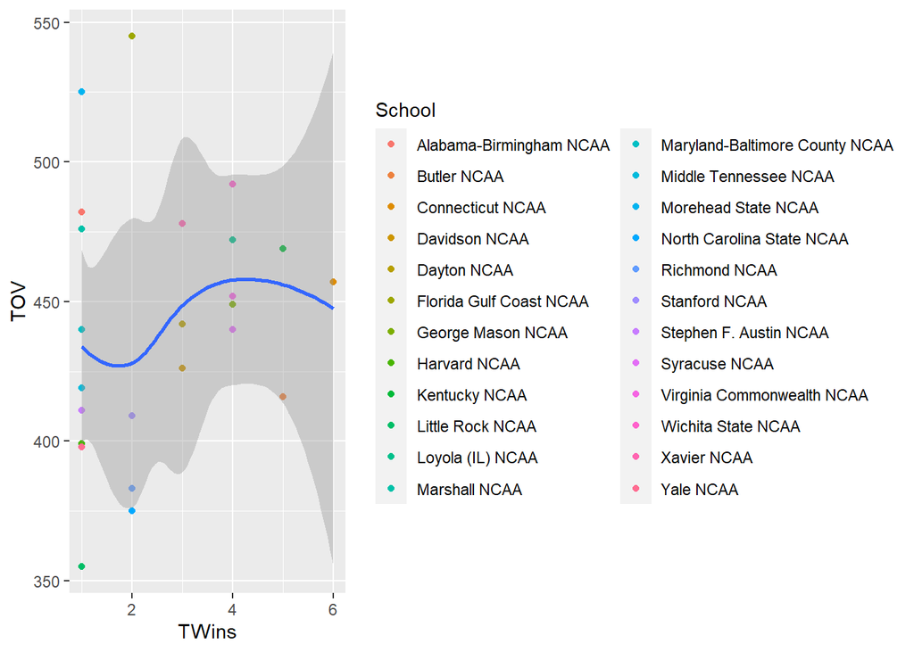

```r
ggplot(combined)+geom_point(aes(x = TWins, y=TOV, color = School))+geom_smooth(aes(x = TWins, y=TOV))
```

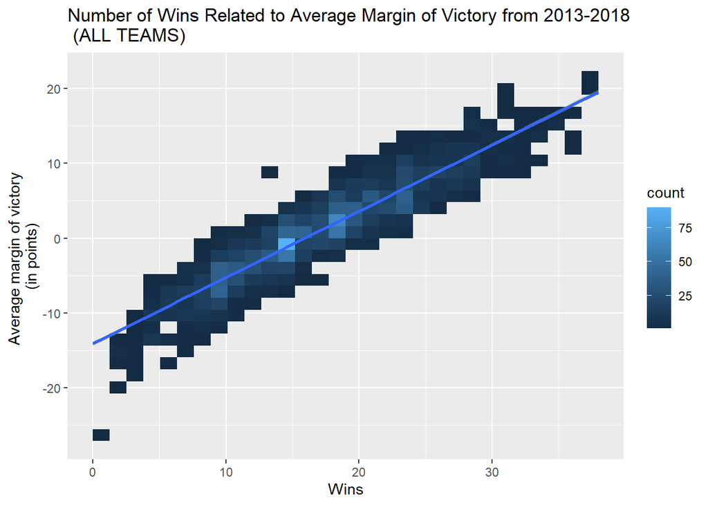

```r
ggplot(allCombinedYears)+geom_bin2d(aes(x = W, y=avMarg))+geom_smooth(method= 'lm',aes(x = W, y=avMarg))+ggtitle("Number of Wins Related to Average Margin of Victory from 2013-2018 \n (ALL TEAMS)")+ xlab("Wins")+ ylab("Average margin of victory \n (in points) ")
```

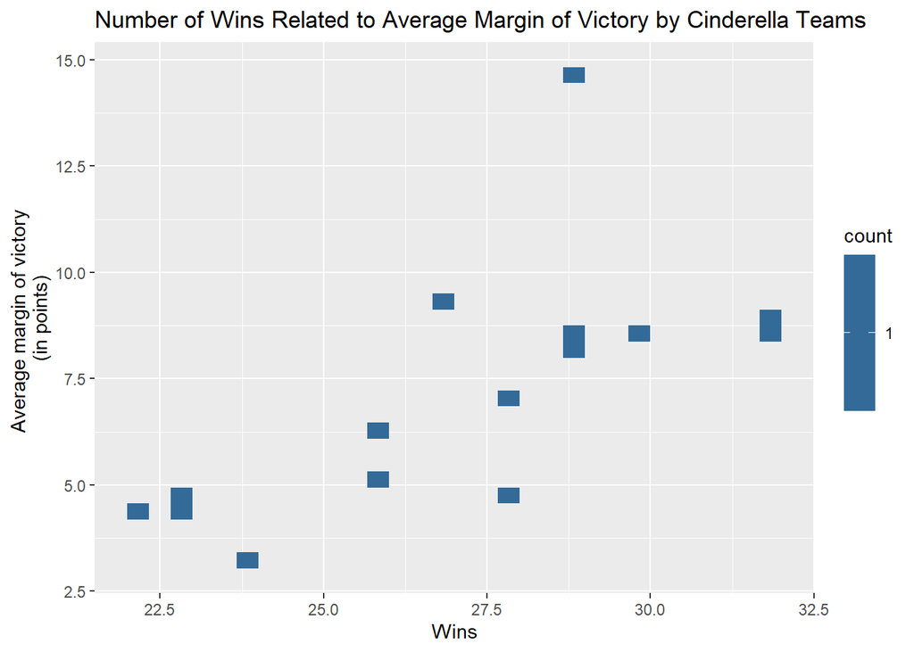

```r
ggplot(cinderella)+geom_bin2d(aes(x = W, y=avMarg))+ggtitle("Number of Wins Related to Average Margin of Victory by Cinderella Teams")+ xlab("Wins")+ ylab("Average margin of victory \n (in points) ")
```

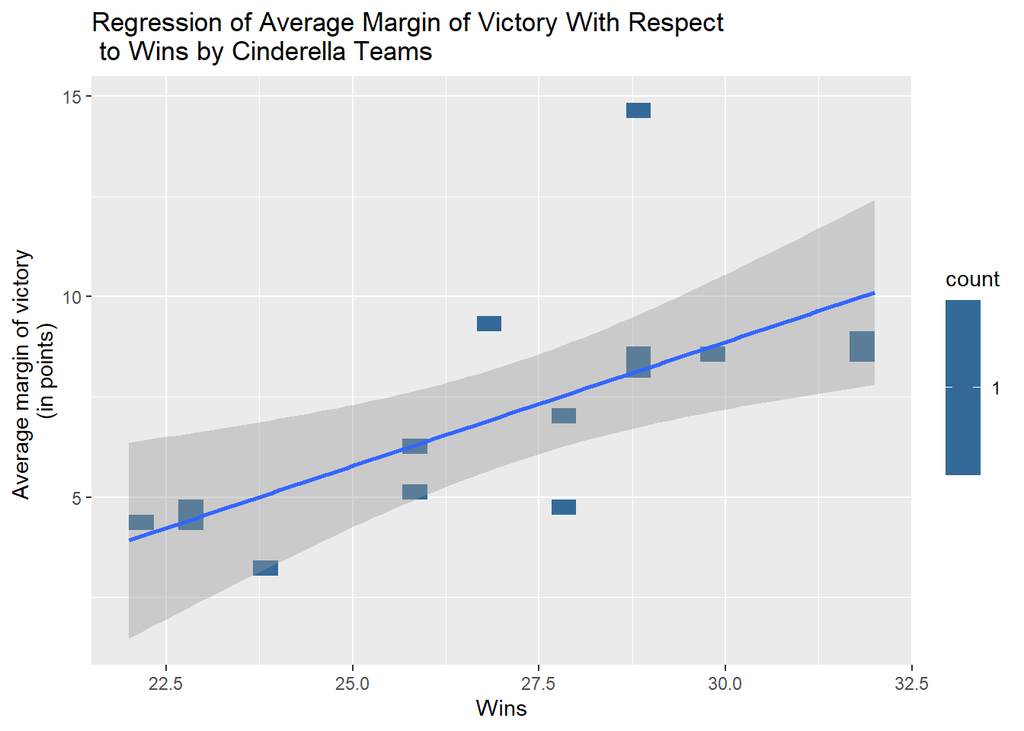

```r
ggplot(cinderella)+geom_bin2d(aes(x = W, y=avMarg))+geom_smooth(method = 'lm', aes(x = W, y=avMarg))+ggtitle("Regression of Average Margin of Victory With Respect \n to Wins by Cinderella Teams")+ xlab("Wins")+ ylab("Average margin of victory \n (in points) ")
```

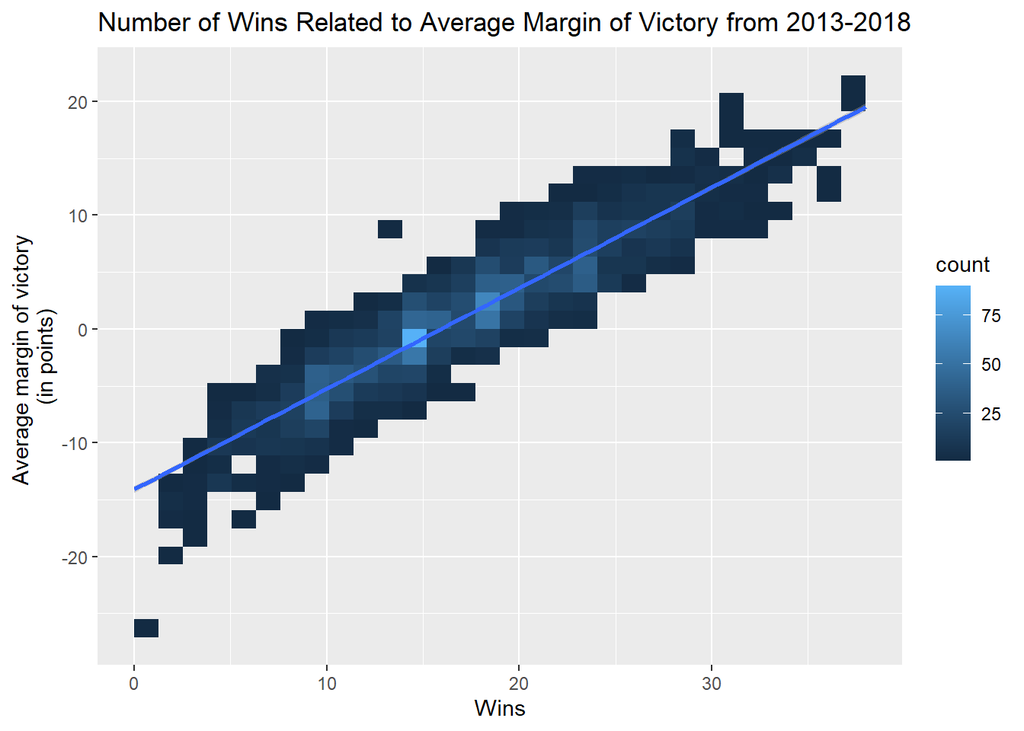

```r
ggplot(allCombinedYears)+geom_bin2d(aes(x = W, y=avMarg))+geom_smooth(method= 'lm',aes(x = W, y=avMarg))+ggtitle("Number of Wins Related to Average Margin of Victory from 2013-2018")+ xlab("Wins")+ ylab("Average margin of victory \n (in points) ")
```

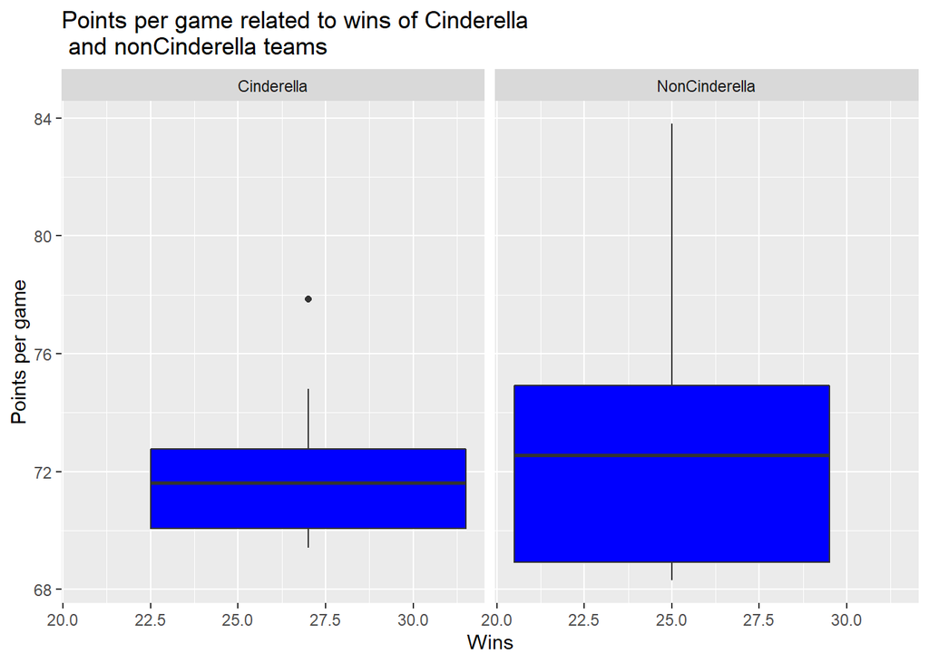

```r
ggplot(combined)+geom_boxplot(aes(x = W, y=ppg),fill = 'blue')+facet_wrap(~cinderellaStat)+ggtitle("Points per game related to wins of Cinderella \n and nonCinderella teams")+ xlab("Wins")+ ylab("Points per game")
```

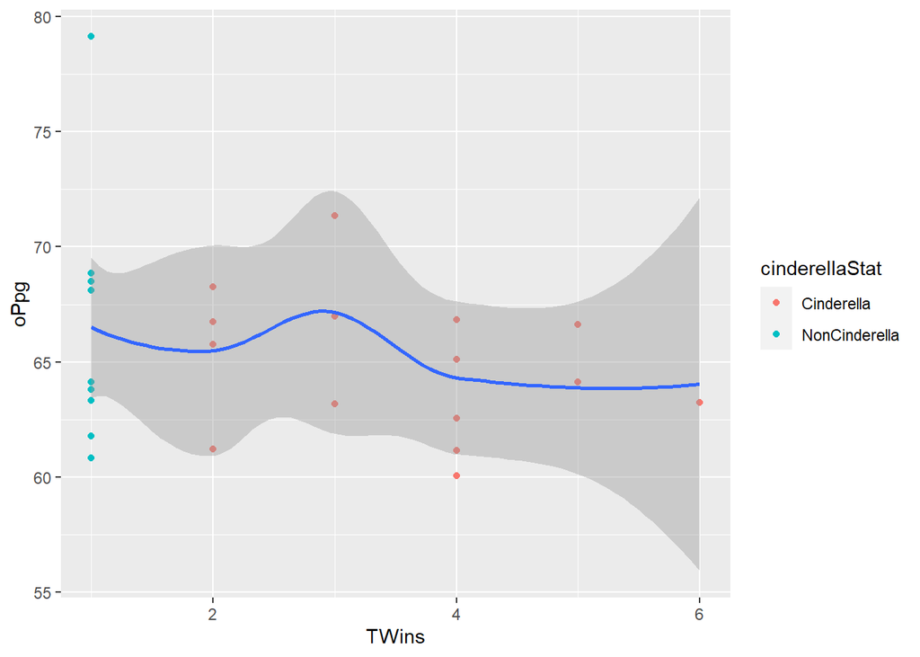

```r
ggplot(combined)+geom_point(aes(x = TWins, y=oPpg, color = cinderellaStat))+geom_smooth(aes(x = TWins, y=oPpg))
```

```r
cor(combined$TWins,combined$oPpg)
```

```
## [1] -0.2459223
```

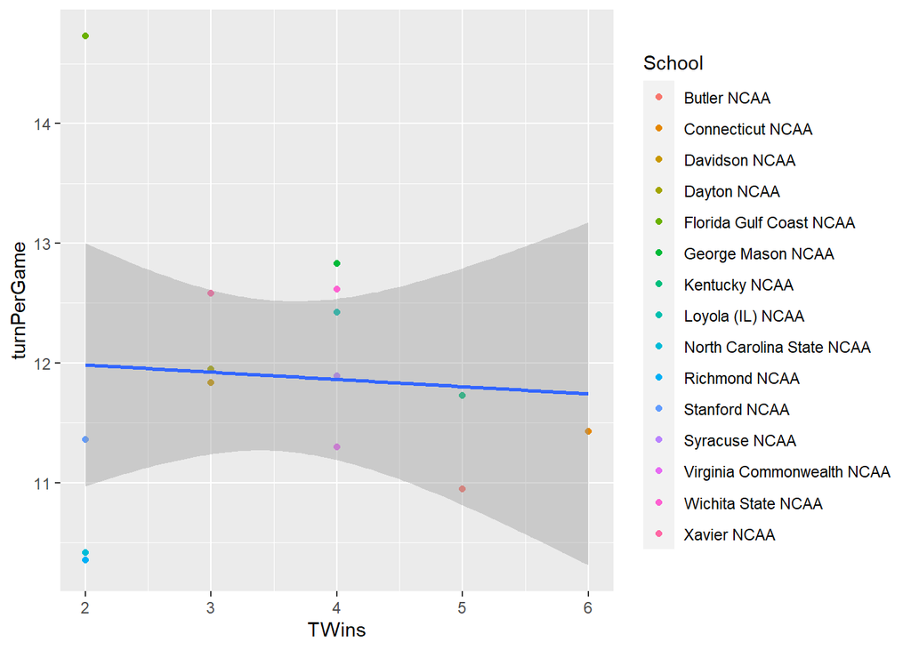

```r
ggplot(cinderella)+geom_point(aes(x = TWins, y=turnPerGame, color = School))+geom_smooth(method = 'lm',aes(x = TWins, y=turnPerGame))
```

```r
cor(combined$TWins,combined$oPpg)
```

```
## [1] -0.2459223
```

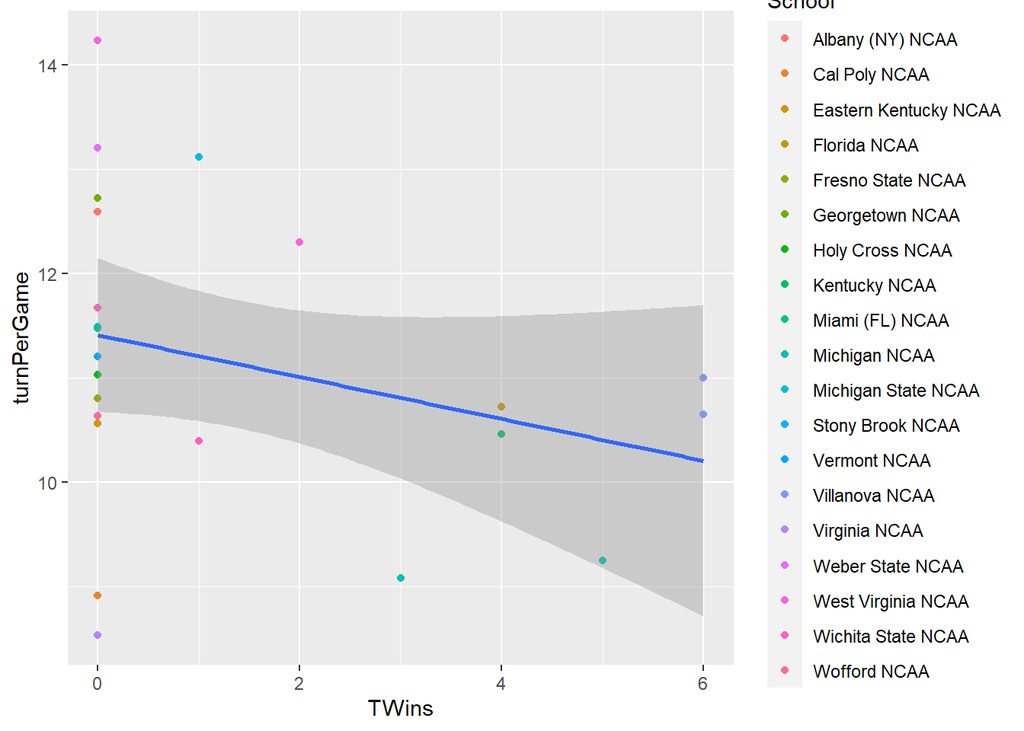

```r
ggplot(balancers)+geom_point(aes(x = TWins, y=turnPerGame, color = School))+geom_smooth(method = 'lm', aes(x = TWins, y=turnPerGame))
```

```r
cor(combined$TWins,combined$oPpg)
```

```
## [1] -0.2459223
```

```r
#CREATE A MODEL THAT PREDICTS THE AMOUNT OF TOURNAMENT WINS A TEAM WILL HAVE BASED ON TURNOVERS OR AV MARGIN AND RUN IT ON THE 2019 TEAMS
```